# Final Presentation

December 2, 2016

## Research Question

**In the US, do traditional indicators of individual voter turnout hold the same predictive power across generations?**

Traditional indicators of voter turnout:

- income
- age
- occupation
- education
- Past voting decisions

For example, education is a traditional indicator used to assess the liklihood that you'll vote, but how strong is it for the Millenials compared to Baby Boomers? Are there other variables that would hold more predictive power for Millenials, such as race or gender?

## Why it matters

Approximately **69.2 million Millenials** are of voting age and are eligible to vote, making them the largest share of eligible voters. Yet…

- In the 2008 presidential election, 50% voted
- In the 2012 presidential election, 46% voted
- In the 2016 presidential election, had only millennials voted, Clinton would've won the election in a landslide - 473 electoral votes to Trump's 32.

And…

- Millenials are demographically much more diverse than previous generations
- Millenials came of age in a very secular and technology driven world

## Methodology

We opted for a logit model because we want to assess if traditional indicators hold the same predictive power across generations.

Our dependent variable is binary: 0 - did not vote in 2012, 1 - voted in 2012.

Independent variables (same model across 4 generations) are:

- education
- gender (female dummy)
- income
- race (black and hispanic dummies)
- whether respondent voted in 2008

## Choice of Data

- American National Election Studies
- Face to face and internet survey, N = 4,505
- Response Rates:
  - Face-to-face: 38 percent
  - Online: 2 percent
- Over 1,900 variables
- Conducted in English and Spanish
- Weighted survey

## Model results

-Expressed as odds-ratios (exponentiated coefficients), so can be interpreted as factor change in odds of voting in 2012

|  | *Dependent variable:* |  |  |  |
| --- | --- | --- | --- | --- |
|  | Probability of voting in 2012 |  |  |  |
|  | Gen Y | Gen X | Boomers | Silent |
|  | (1) | (2) | (3) | (4) |
| education | 1.317*** | 1.133*** | 1.377*** | 1.404*** |
|  | (0.134) | (0.118) | (0.120) | (0.192) |
| female | 1.112*** | 1.360*** | 1.206*** | 0.484 |
|  | (0.235) | (0.247) | (0.253) | (0.481) |
| vote_2008 | 2.956*** | 6.727*** | 14.474*** | 23.935*** |
|  | (0.248) | (0.271) | (0.254) | (0.625) |
| black | 2.640*** | 1.567*** | 0.482 | 6.277*** |
|  | (0.393) | (0.426) | (0.357) | (0.869) |
| hispanic | 1.878*** | 0.680** | 0.883** | 0.262 |
|  | (0.352) | (0.298) | (0.390) | (0.832) |
| income | 1.217*** | 1.161*** | 1.196*** | 1.665*** |
|  | (0.079) | (0.087) | (0.069) | (0.215) |
| Constant | 0.240 | 0.378 | 0.224 | 0.144 |
|  | (0.413) | (0.495) | (0.444) | (0.812) |
| Observations | 750 | 988 | 1,745 | 698 |
| *Note:* | p<0.1; p<0.05; p<0.01 |  |  |  |

## How the model plays out in simulation

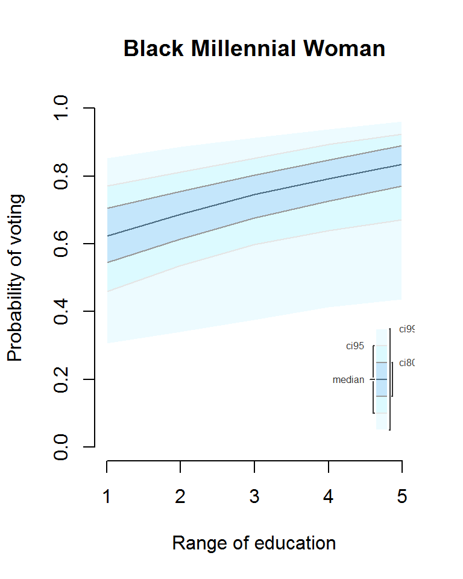

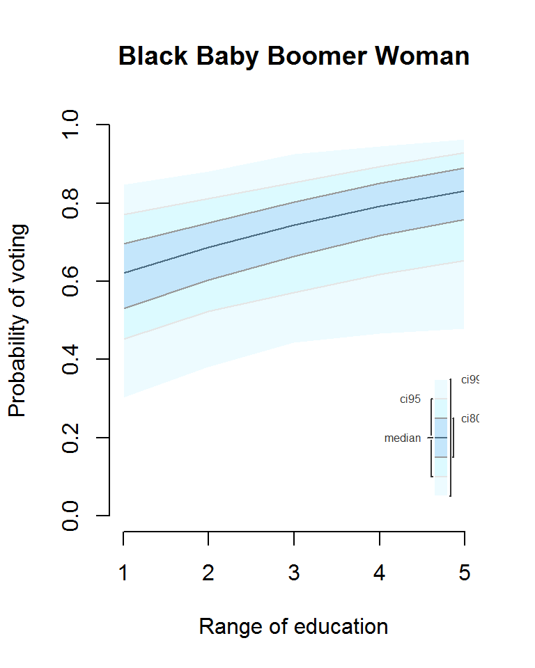

## How the model plays out in simulation (part 2)

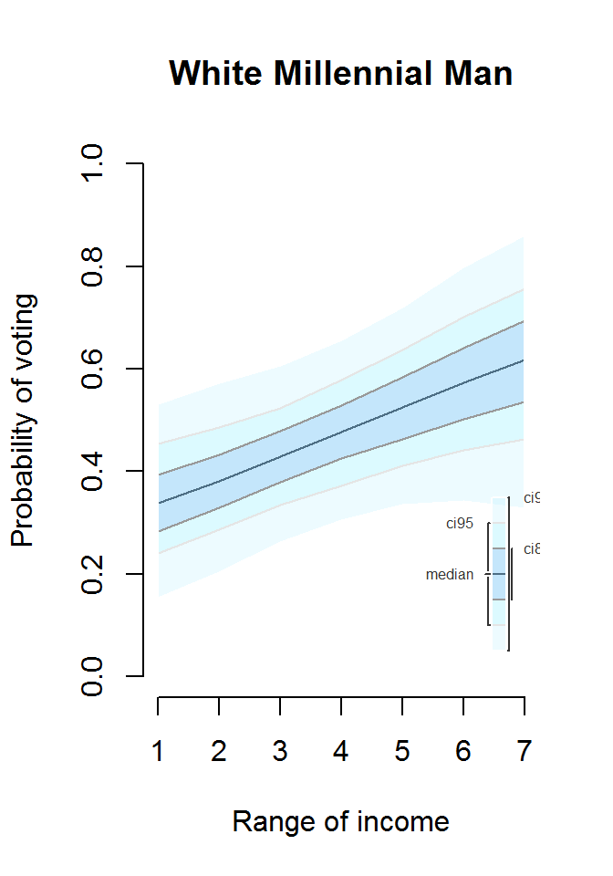

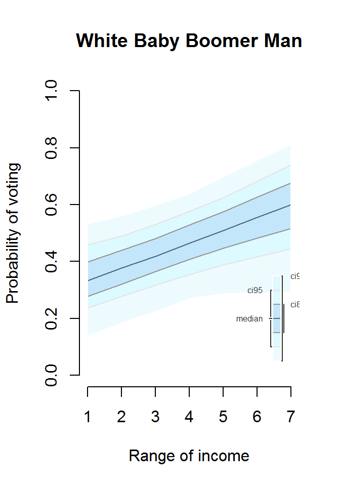

## How the model plays out in simulation (part 3)

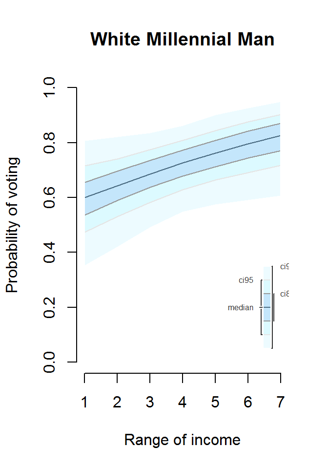

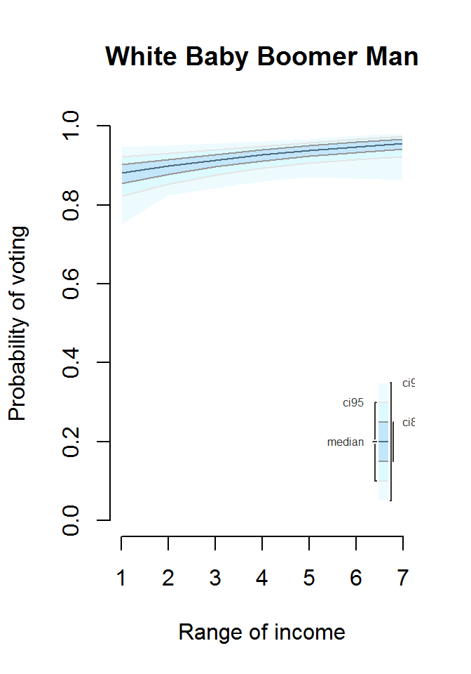

## Limitations

- Issues with external validity
- Relavtively low survey response
- Self survey & self report
- Goodness of Fit

## Goodness of Fit (Likelihood-ratio test)

Does the model with predictors fit significantly better than a model with just an intercept (a null model)?

```r
with(M_genY, null.deviance - deviance) #gives chi-square value
```

```
## [1] 82.22611
```

```r
with(M_genY, df.null - df.residual) #gives degrees of freedom
```

```
## [1] 231
```

```r
with(M_genY, pchisq(null.deviance - deviance,
                    df.null - df.residual,
                    lower.tail = FALSE)) #gives p value
```

```
## [1] 1
```

## Goodness of Fit (ROC)

Receiver operating characteristic plot

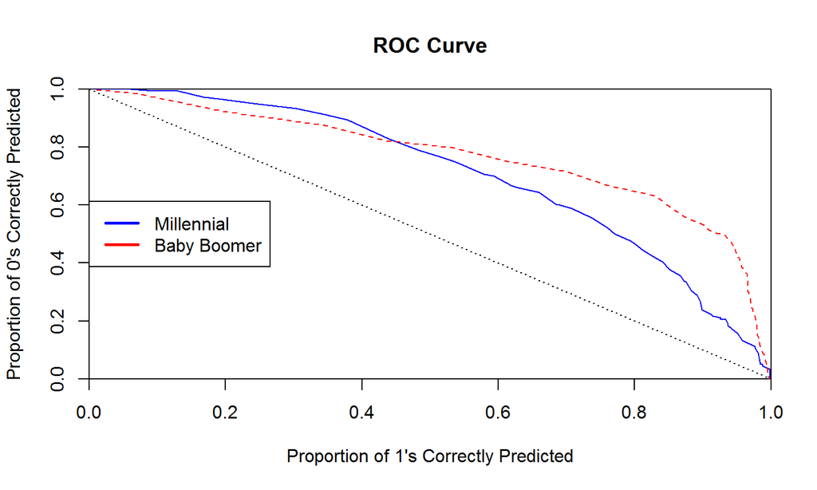